# Risk Factor Analysis

## Outcome Variable

**Outcome Variable:** ever_stunted

## Predictor Variables

**Intervention Variable:** predfeed3

**Adjustment Set:**

- arm
- month
- brthmon
- W_mage
- meducyrs
- feducyrs
- hhwealth_quart
- hfoodsec
- W_mhtcm
- W_mwtkg
- W_mbmi
- vagbrth
- W_gagebrth
- W_birthwt
- W_birthlen
- W_nrooms
- W_nchldlt5
- W_parity
- impfloor
- impsan
- safeh20
- delta_W_mage
- delta_meducyrs
- delta_feducyrs
- delta_hhwealth_quart
- delta_hfoodsec
- delta_W_mhtcm
- delta_W_mwtkg
- delta_W_mbmi
- delta_vagbrth
- delta_W_gagebrth
- delta_W_birthwt
- delta_W_birthlen
- delta_W_nrooms
- delta_W_nchldlt5
- delta_W_parity
- delta_impfloor
- delta_impsan
- delta_safeh20

## Stratifying Variables

The analysis was stratified on these variable(s):

- agecat
- studyid
- country

## Data Summary

| agecat | studyid | country | predfeed3 | ever_stunted | n_cell | n |
| --- | --- | --- | --- | --- | --- | --- |
| 0-24 months (no birth st.) | ki0047075b-MAL-ED | BANGLADESH | 1 | 0 | 78 | 202 |
| 0-24 months (no birth st.) | ki0047075b-MAL-ED | BANGLADESH | 1 | 1 | 86 | 202 |
| 0-24 months (no birth st.) | ki0047075b-MAL-ED | BANGLADESH | 0 | 0 | 16 | 202 |
| 0-24 months (no birth st.) | ki0047075b-MAL-ED | BANGLADESH | 0 | 1 | 22 | 202 |
| 0-24 months (no birth st.) | ki0047075b-MAL-ED | BRAZIL | 1 | 0 | 69 | 175 |
| 0-24 months (no birth st.) | ki0047075b-MAL-ED | BRAZIL | 1 | 1 | 17 | 175 |
| 0-24 months (no birth st.) | ki0047075b-MAL-ED | BRAZIL | 0 | 0 | 75 | 175 |
| 0-24 months (no birth st.) | ki0047075b-MAL-ED | BRAZIL | 0 | 1 | 14 | 175 |
| 0-24 months (no birth st.) | ki0047075b-MAL-ED | INDIA | 1 | 0 | 48 | 184 |
| 0-24 months (no birth st.) | ki0047075b-MAL-ED | INDIA | 1 | 1 | 79 | 184 |
| 0-24 months (no birth st.) | ki0047075b-MAL-ED | INDIA | 0 | 0 | 35 | 184 |
| 0-24 months (no birth st.) | ki0047075b-MAL-ED | INDIA | 0 | 1 | 22 | 184 |
| 0-24 months (no birth st.) | ki0047075b-MAL-ED | NEPAL | 1 | 0 | 77 | 201 |
| 0-24 months (no birth st.) | ki0047075b-MAL-ED | NEPAL | 1 | 1 | 28 | 201 |
| 0-24 months (no birth st.) | ki0047075b-MAL-ED | NEPAL | 0 | 0 | 72 | 201 |
| 0-24 months (no birth st.) | ki0047075b-MAL-ED | NEPAL | 0 | 1 | 24 | 201 |
| 0-24 months (no birth st.) | ki0047075b-MAL-ED | PERU | 1 | 0 | 71 | 253 |
| 0-24 months (no birth st.) | ki0047075b-MAL-ED | PERU | 1 | 1 | 95 | 253 |
| 0-24 months (no birth st.) | ki0047075b-MAL-ED | PERU | 0 | 0 | 31 | 253 |
| 0-24 months (no birth st.) | ki0047075b-MAL-ED | PERU | 0 | 1 | 56 | 253 |
| 0-24 months (no birth st.) | ki0047075b-MAL-ED | SOUTH AFRICA | 1 | 0 | 31 | 237 |
| 0-24 months (no birth st.) | ki0047075b-MAL-ED | SOUTH AFRICA | 1 | 1 | 35 | 237 |
| 0-24 months (no birth st.) | ki0047075b-MAL-ED | SOUTH AFRICA | 0 | 0 | 75 | 237 |
| 0-24 months (no birth st.) | ki0047075b-MAL-ED | SOUTH AFRICA | 0 | 1 | 96 | 237 |
| 0-24 months (no birth st.) | ki0047075b-MAL-ED | TANZANIA, UNITED REPUBLIC OF | 1 | 0 | 10 | 185 |
| 0-24 months (no birth st.) | ki0047075b-MAL-ED | TANZANIA, UNITED REPUBLIC OF | 1 | 1 | 46 | 185 |
| 0-24 months (no birth st.) | ki0047075b-MAL-ED | TANZANIA, UNITED REPUBLIC OF | 0 | 0 | 20 | 185 |
| 0-24 months (no birth st.) | ki0047075b-MAL-ED | TANZANIA, UNITED REPUBLIC OF | 0 | 1 | 109 | 185 |
| 0-24 months (no birth st.) | ki1000109-EE | PAKISTAN | 1 | 0 | 4 | 21 |
| 0-24 months (no birth st.) | ki1000109-EE | PAKISTAN | 1 | 1 | 17 | 21 |

[output cut: 102 more lines]

The following strata were considered:

- agecat: 0-24 months (no birth st.), studyid: ki0047075b-MAL-ED, country: BANGLADESH
- agecat: 0-24 months (no birth st.), studyid: ki0047075b-MAL-ED, country: BRAZIL
- agecat: 0-24 months (no birth st.), studyid: ki0047075b-MAL-ED, country: INDIA
- agecat: 0-24 months (no birth st.), studyid: ki0047075b-MAL-ED, country: NEPAL
- agecat: 0-24 months (no birth st.), studyid: ki0047075b-MAL-ED, country: PERU
- agecat: 0-24 months (no birth st.), studyid: ki0047075b-MAL-ED, country: SOUTH AFRICA
- agecat: 0-24 months (no birth st.), studyid: ki0047075b-MAL-ED, country: TANZANIA, UNITED REPUBLIC OF
- agecat: 0-24 months (no birth st.), studyid: ki1000109-EE, country: PAKISTAN
- agecat: 0-24 months (no birth st.), studyid: ki1113344-GMS-Nepal, country: NEPAL
- agecat: 0-24 months (no birth st.), studyid: kiGH5241-JiVitA-3, country: BANGLADESH
- agecat: 0-24 months (no birth st.), studyid: kiGH5241-JiVitA-4, country: BANGLADESH
- agecat: 0-6 months (no birth st.), studyid: ki0047075b-MAL-ED, country: BANGLADESH
- agecat: 0-6 months (no birth st.), studyid: ki0047075b-MAL-ED, country: BRAZIL
- agecat: 0-6 months (no birth st.), studyid: ki0047075b-MAL-ED, country: INDIA
- agecat: 0-6 months (no birth st.), studyid: ki0047075b-MAL-ED, country: NEPAL
- agecat: 0-6 months (no birth st.), studyid: ki0047075b-MAL-ED, country: PERU
- agecat: 0-6 months (no birth st.), studyid: ki0047075b-MAL-ED, country: SOUTH AFRICA
- agecat: 0-6 months (no birth st.), studyid: ki0047075b-MAL-ED, country: TANZANIA, UNITED REPUBLIC OF
- agecat: 0-6 months (no birth st.), studyid: ki1000109-EE, country: PAKISTAN
- agecat: 0-6 months (no birth st.), studyid: ki1113344-GMS-Nepal, country: NEPAL
- agecat: 0-6 months (no birth st.), studyid: kiGH5241-JiVitA-3, country: BANGLADESH
- agecat: 0-6 months (no birth st.), studyid: kiGH5241-JiVitA-4, country: BANGLADESH
- agecat: 6-24 months, studyid: ki0047075b-MAL-ED, country: BANGLADESH
- agecat: 6-24 months, studyid: ki0047075b-MAL-ED, country: BRAZIL
- agecat: 6-24 months, studyid: ki0047075b-MAL-ED, country: INDIA
- agecat: 6-24 months, studyid: ki0047075b-MAL-ED, country: NEPAL
- agecat: 6-24 months, studyid: ki0047075b-MAL-ED, country: PERU
- agecat: 6-24 months, studyid: ki0047075b-MAL-ED, country: SOUTH AFRICA
- agecat: 6-24 months, studyid: ki0047075b-MAL-ED, country: TANZANIA, UNITED REPUBLIC OF
- agecat: 6-24 months, studyid: ki1000109-EE, country: PAKISTAN
- agecat: 6-24 months, studyid: ki1113344-GMS-Nepal, country: NEPAL
- agecat: 6-24 months, studyid: kiGH5241-JiVitA-3, country: BANGLADESH
- agecat: 6-24 months, studyid: kiGH5241-JiVitA-4, country: BANGLADESH

### Dropped Strata

Some strata were dropped due to rare outcomes:

- agecat: 0-24 months (no birth st.), studyid: ki1000109-EE, country: PAKISTAN
- agecat: 0-24 months (no birth st.), studyid: kiGH5241-JiVitA-4, country: BANGLADESH
- agecat: 0-6 months (no birth st.), studyid: ki0047075b-MAL-ED, country: NEPAL
- agecat: 0-6 months (no birth st.), studyid: ki1000109-EE, country: PAKISTAN
- agecat: 0-6 months (no birth st.), studyid: kiGH5241-JiVitA-4, country: BANGLADESH
- agecat: 6-24 months, studyid: ki1000109-EE, country: PAKISTAN
- agecat: 6-24 months, studyid: kiGH5241-JiVitA-4, country: BANGLADESH

## Methods Detail

We’re interested in the causal parameters $E[Y_a]$ for all values of $a \in \mathcal{A}$. These parameters represent the mean outcome if, possibly contrary to fact, we intervened to set all units to have $A=a$. Under the randomization and positivity assumptions, these are identified by the statistical parameters $\psi_a=E_W[E_{Y|A,W}(Y|A=a,W)]$. In addition, we’re interested in the mean of $Y$, $E[Y]$ under no intervention (the observed mean). We will estimate these parameters by using SuperLearner to fit the relevant likelihood factors – $E_{Y|A,W}(Y|A=a,W)$ and $p(A=a|W)$, and then updating our likelihood fit using a joint TMLE.

For unadjusted analyses ($W=\{\}$), initial likelihoods were estimated using Lrnr_glm to estimate the simple $E(Y|A)$ and Lrnr_mean to estimate $p(A)$. For adjusted analyses, a small library containing Lrnr_glmnet, Lrnr_xgboost, and Lrnr_mean was used.

Having estimated these parameters, we will then use the delta method to estimate relative risks and attributable risks relative to a prespecified baseline level of $A$.

# Results Detail

## Results Plots

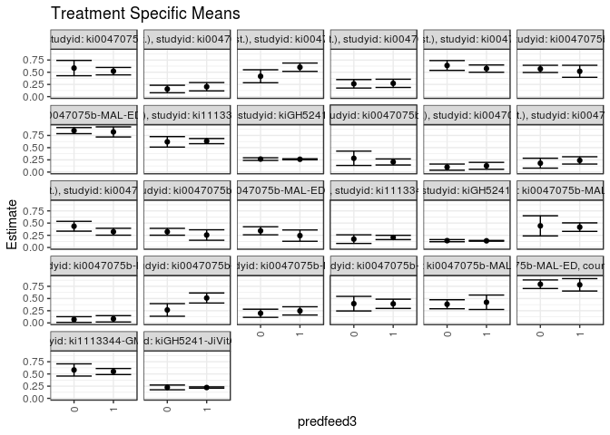

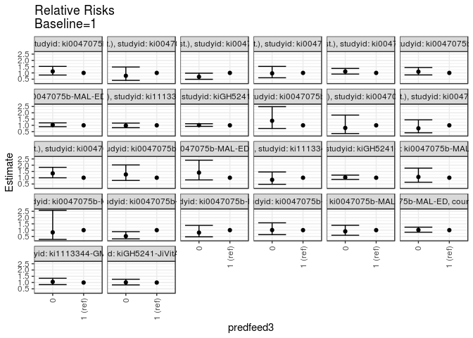

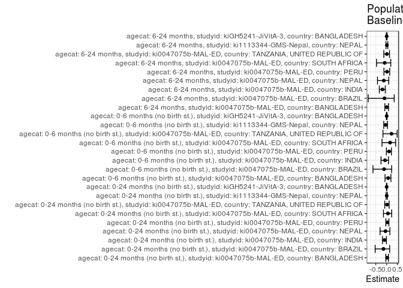

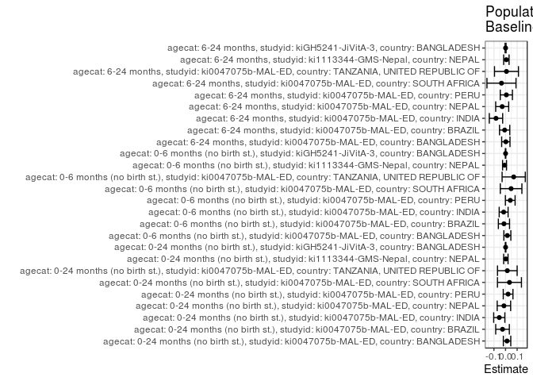

## Results Table

### Parameter: TSM

| agecat | studyid | country | intervention_level | baseline_level | estimate | ci_lower | ci_upper |
| --- | --- | --- | --- | --- | --- | --- | --- |
| 0-24 months (no birth st.) | ki0047075b-MAL-ED | BANGLADESH | 1 | NA | 0.5216002 | 0.4452917 | 0.5979086 |
| 0-24 months (no birth st.) | ki0047075b-MAL-ED | BANGLADESH | 0 | NA | 0.5852181 | 0.4282974 | 0.7421388 |
| 0-24 months (no birth st.) | ki0047075b-MAL-ED | BRAZIL | 1 | NA | 0.2030403 | 0.1180551 | 0.2880255 |
| 0-24 months (no birth st.) | ki0047075b-MAL-ED | BRAZIL | 0 | NA | 0.1564278 | 0.0796475 | 0.2332081 |
| 0-24 months (no birth st.) | ki0047075b-MAL-ED | INDIA | 1 | NA | 0.6028166 | 0.5176505 | 0.6879828 |
| 0-24 months (no birth st.) | ki0047075b-MAL-ED | INDIA | 0 | NA | 0.4175500 | 0.2849711 | 0.5501290 |
| 0-24 months (no birth st.) | ki0047075b-MAL-ED | NEPAL | 1 | NA | 0.2725430 | 0.1882902 | 0.3567958 |
| 0-24 months (no birth st.) | ki0047075b-MAL-ED | NEPAL | 0 | NA | 0.2628516 | 0.1760484 | 0.3496549 |
| 0-24 months (no birth st.) | ki0047075b-MAL-ED | PERU | 1 | NA | 0.5747630 | 0.5002043 | 0.6493217 |
| 0-24 months (no birth st.) | ki0047075b-MAL-ED | PERU | 0 | NA | 0.6380712 | 0.5376917 | 0.7384506 |
| 0-24 months (no birth st.) | ki0047075b-MAL-ED | SOUTH AFRICA | 1 | NA | 0.5190182 | 0.3960627 | 0.6419737 |
| 0-24 months (no birth st.) | ki0047075b-MAL-ED | SOUTH AFRICA | 0 | NA | 0.5686404 | 0.4946960 | 0.6425847 |
| 0-24 months (no birth st.) | ki0047075b-MAL-ED | TANZANIA, UNITED REPUBLIC OF | 1 | NA | 0.8223840 | 0.7190179 | 0.9257501 |
| 0-24 months (no birth st.) | ki0047075b-MAL-ED | TANZANIA, UNITED REPUBLIC OF | 0 | NA | 0.8486970 | 0.7861562 | 0.9112378 |
| 0-24 months (no birth st.) | ki1113344-GMS-Nepal | NEPAL | 1 | NA | 0.6340929 | 0.5813100 | 0.6868759 |
| 0-24 months (no birth st.) | ki1113344-GMS-Nepal | NEPAL | 0 | NA | 0.6193820 | 0.5120730 | 0.7266910 |
| 0-24 months (no birth st.) | kiGH5241-JiVitA-3 | BANGLADESH | 1 | NA | 0.2623182 | 0.2515240 | 0.2731123 |
| 0-24 months (no birth st.) | kiGH5241-JiVitA-3 | BANGLADESH | 0 | NA | 0.2662564 | 0.2395282 | 0.2929847 |
| 0-6 months (no birth st.) | ki0047075b-MAL-ED | BANGLADESH | 1 | NA | 0.2070865 | 0.1448133 | 0.2693598 |
| 0-6 months (no birth st.) | ki0047075b-MAL-ED | BANGLADESH | 0 | NA | 0.2821796 | 0.1353182 | 0.4290409 |
| 0-6 months (no birth st.) | ki0047075b-MAL-ED | BRAZIL | 1 | NA | 0.1279070 | 0.0571170 | 0.1986970 |
| 0-6 months (no birth st.) | ki0047075b-MAL-ED | BRAZIL | 0 | NA | 0.1011236 | 0.0383071 | 0.1639401 |
| 0-6 months (no birth st.) | ki0047075b-MAL-ED | INDIA | 1 | NA | 0.2390868 | 0.1642129 | 0.3139608 |
| 0-6 months (no birth st.) | ki0047075b-MAL-ED | INDIA | 0 | NA | 0.1819665 | 0.0803863 | 0.2835467 |
| 0-6 months (no birth st.) | ki0047075b-MAL-ED | PERU | 1 | NA | 0.3230577 | 0.2526763 | 0.3934391 |
| 0-6 months (no birth st.) | ki0047075b-MAL-ED | PERU | 0 | NA | 0.4354503 | 0.3347914 | 0.5361092 |
| 0-6 months (no birth st.) | ki0047075b-MAL-ED | SOUTH AFRICA | 1 | NA | 0.2558858 | 0.1487345 | 0.3630371 |
| 0-6 months (no birth st.) | ki0047075b-MAL-ED | SOUTH AFRICA | 0 | NA | 0.3222505 | 0.2519459 | 0.3925550 |
| 0-6 months (no birth st.) | ki0047075b-MAL-ED | TANZANIA, UNITED REPUBLIC OF | 1 | NA | 0.2432535 | 0.1276801 | 0.3588269 |
| 0-6 months (no birth st.) | ki0047075b-MAL-ED | TANZANIA, UNITED REPUBLIC OF | 0 | NA | 0.3421206 | 0.2596359 | 0.4246054 |
| 0-6 months (no birth st.) | ki1113344-GMS-Nepal | NEPAL | 1 | NA | 0.2058751 | 0.1613305 | 0.2504197 |
| 0-6 months (no birth st.) | ki1113344-GMS-Nepal | NEPAL | 0 | NA | 0.1718072 | 0.0832625 | 0.2603520 |
| 0-6 months (no birth st.) | kiGH5241-JiVitA-3 | BANGLADESH | 1 | NA | 0.1368985 | 0.1289492 | 0.1448478 |
| 0-6 months (no birth st.) | kiGH5241-JiVitA-3 | BANGLADESH | 0 | NA | 0.1401930 | 0.1181812 | 0.1622048 |
| 6-24 months | ki0047075b-MAL-ED | BANGLADESH | 1 | NA | 0.4174568 | 0.3305290 | 0.5043846 |
| 6-24 months | ki0047075b-MAL-ED | BANGLADESH | 0 | NA | 0.4436160 | 0.2369380 | 0.6502940 |
| 6-24 months | ki0047075b-MAL-ED | BRAZIL | 1 | NA | 0.0845070 | 0.0195813 | 0.1494328 |
| 6-24 months | ki0047075b-MAL-ED | BRAZIL | 0 | NA | 0.0694444 | 0.0105200 | 0.1283689 |
| 6-24 months | ki0047075b-MAL-ED | INDIA | 1 | NA | 0.5106933 | 0.4077854 | 0.6136013 |
| 6-24 months | ki0047075b-MAL-ED | INDIA | 0 | NA | 0.2657717 | 0.1364152 | 0.3951282 |
| 6-24 months | ki0047075b-MAL-ED | NEPAL | 1 | NA | 0.2468007 | 0.1621928 | 0.3314087 |
| 6-24 months | ki0047075b-MAL-ED | NEPAL | 0 | NA | 0.1978017 | 0.1145791 | 0.2810243 |
| 6-24 months | ki0047075b-MAL-ED | PERU | 1 | NA | 0.3916352 | 0.2968283 | 0.4864422 |
| 6-24 months | ki0047075b-MAL-ED | PERU | 0 | NA | 0.3946804 | 0.2450805 | 0.5442802 |
| 6-24 months | ki0047075b-MAL-ED | SOUTH AFRICA | 1 | NA | 0.4230613 | 0.2750030 | 0.5711196 |
| 6-24 months | ki0047075b-MAL-ED | SOUTH AFRICA | 0 | NA | 0.3827867 | 0.2901851 | 0.4753883 |
| 6-24 months | ki0047075b-MAL-ED | TANZANIA, UNITED REPUBLIC OF | 1 | NA | 0.7804878 | 0.6532720 | 0.9077036 |
| 6-24 months | ki0047075b-MAL-ED | TANZANIA, UNITED REPUBLIC OF | 0 | NA | 0.7926829 | 0.7045819 | 0.8807840 |
| 6-24 months | ki1113344-GMS-Nepal | NEPAL | 1 | NA | 0.5494604 | 0.4876755 | 0.6112452 |
| 6-24 months | ki1113344-GMS-Nepal | NEPAL | 0 | NA | 0.5814295 | 0.4564019 | 0.7064571 |
| 6-24 months | kiGH5241-JiVitA-3 | BANGLADESH | 1 | NA | 0.2216655 | 0.2087159 | 0.2346151 |
| 6-24 months | kiGH5241-JiVitA-3 | BANGLADESH | 0 | NA | 0.2243530 | 0.1759586 | 0.2727475 |

### Parameter: E(Y)

| agecat | studyid | country | intervention_level | baseline_level | estimate | ci_lower | ci_upper |
| --- | --- | --- | --- | --- | --- | --- | --- |
| 0-24 months (no birth st.) | ki0047075b-MAL-ED | BANGLADESH | NA | NA | 0.5346535 | 0.4656971 | 0.6036099 |
| 0-24 months (no birth st.) | ki0047075b-MAL-ED | BRAZIL | NA | NA | 0.1771429 | 0.1204149 | 0.2338709 |
| 0-24 months (no birth st.) | ki0047075b-MAL-ED | INDIA | NA | NA | 0.5489130 | 0.4768182 | 0.6210079 |
| 0-24 months (no birth st.) | ki0047075b-MAL-ED | NEPAL | NA | NA | 0.2587065 | 0.1980144 | 0.3193985 |
| 0-24 months (no birth st.) | ki0047075b-MAL-ED | PERU | NA | NA | 0.5968379 | 0.5362738 | 0.6574021 |
| 0-24 months (no birth st.) | ki0047075b-MAL-ED | SOUTH AFRICA | NA | NA | 0.5527426 | 0.4893071 | 0.6161781 |
| 0-24 months (no birth st.) | ki0047075b-MAL-ED | TANZANIA, UNITED REPUBLIC OF | NA | NA | 0.8378378 | 0.7845787 | 0.8910970 |
| 0-24 months (no birth st.) | ki1113344-GMS-Nepal | NEPAL | NA | NA | 0.6368421 | 0.5884257 | 0.6852585 |
| 0-24 months (no birth st.) | kiGH5241-JiVitA-3 | BANGLADESH | NA | NA | 0.2628104 | 0.2524838 | 0.2731371 |
| 0-6 months (no birth st.) | ki0047075b-MAL-ED | BANGLADESH | NA | NA | 0.2227723 | 0.1652475 | 0.2802970 |
| 0-6 months (no birth st.) | ki0047075b-MAL-ED | BRAZIL | NA | NA | 0.1142857 | 0.0670124 | 0.1615591 |
| 0-6 months (no birth st.) | ki0047075b-MAL-ED | INDIA | NA | NA | 0.2228261 | 0.1625334 | 0.2831188 |
| 0-6 months (no birth st.) | ki0047075b-MAL-ED | PERU | NA | NA | 0.3636364 | 0.3042435 | 0.4230292 |
| 0-6 months (no birth st.) | ki0047075b-MAL-ED | SOUTH AFRICA | NA | NA | 0.3037975 | 0.2451226 | 0.3624723 |
| 0-6 months (no birth st.) | ki0047075b-MAL-ED | TANZANIA, UNITED REPUBLIC OF | NA | NA | 0.3135135 | 0.2464813 | 0.3805457 |
| 0-6 months (no birth st.) | ki1113344-GMS-Nepal | NEPAL | NA | NA | 0.1973684 | 0.1572979 | 0.2374390 |
| 0-6 months (no birth st.) | kiGH5241-JiVitA-3 | BANGLADESH | NA | NA | 0.1373090 | 0.1297510 | 0.1448670 |
| 6-24 months | ki0047075b-MAL-ED | BANGLADESH | NA | NA | 0.4200000 | 0.3407510 | 0.4992490 |
| 6-24 months | ki0047075b-MAL-ED | BRAZIL | NA | NA | 0.0769231 | 0.0330951 | 0.1207510 |
| 6-24 months | ki0047075b-MAL-ED | INDIA | NA | NA | 0.4285714 | 0.3463030 | 0.5108399 |
| 6-24 months | ki0047075b-MAL-ED | NEPAL | NA | NA | 0.2180851 | 0.1588990 | 0.2772712 |
| 6-24 months | ki0047075b-MAL-ED | PERU | NA | NA | 0.3986486 | 0.3194990 | 0.4777982 |
| 6-24 months | ki0047075b-MAL-ED | SOUTH AFRICA | NA | NA | 0.3881579 | 0.3104288 | 0.4658870 |
| 6-24 months | ki0047075b-MAL-ED | TANZANIA, UNITED REPUBLIC OF | NA | NA | 0.7886179 | 0.7161684 | 0.8610674 |
| 6-24 months | ki1113344-GMS-Nepal | NEPAL | NA | NA | 0.5566667 | 0.5003580 | 0.6129753 |
| 6-24 months | kiGH5241-JiVitA-3 | BANGLADESH | NA | NA | 0.2220682 | 0.2093710 | 0.2347655 |

### Parameter: RR

| agecat | studyid | country | intervention_level | baseline_level | estimate | ci_lower | ci_upper |
| --- | --- | --- | --- | --- | --- | --- | --- |
| 0-24 months (no birth st.) | ki0047075b-MAL-ED | BANGLADESH | 1 | 1 | 1.0000000 | 1.0000000 | 1.0000000 |
| 0-24 months (no birth st.) | ki0047075b-MAL-ED | BANGLADESH | 0 | 1 | 1.1219669 | 0.8295470 | 1.5174663 |
| 0-24 months (no birth st.) | ki0047075b-MAL-ED | BRAZIL | 1 | 1 | 1.0000000 | 1.0000000 | 1.0000000 |
| 0-24 months (no birth st.) | ki0047075b-MAL-ED | BRAZIL | 0 | 1 | 0.7704275 | 0.4034603 | 1.4711696 |
| 0-24 months (no birth st.) | ki0047075b-MAL-ED | INDIA | 1 | 1 | 1.0000000 | 1.0000000 | 1.0000000 |
| 0-24 months (no birth st.) | ki0047075b-MAL-ED | INDIA | 0 | 1 | 0.6926651 | 0.4911130 | 0.9769339 |
| 0-24 months (no birth st.) | ki0047075b-MAL-ED | NEPAL | 1 | 1 | 1.0000000 | 1.0000000 | 1.0000000 |
| 0-24 months (no birth st.) | ki0047075b-MAL-ED | NEPAL | 0 | 1 | 0.9644411 | 0.6135440 | 1.5160228 |
| 0-24 months (no birth st.) | ki0047075b-MAL-ED | PERU | 1 | 1 | 1.0000000 | 1.0000000 | 1.0000000 |
| 0-24 months (no birth st.) | ki0047075b-MAL-ED | PERU | 0 | 1 | 1.1101465 | 0.9088226 | 1.3560678 |
| 0-24 months (no birth st.) | ki0047075b-MAL-ED | SOUTH AFRICA | 1 | 1 | 1.0000000 | 1.0000000 | 1.0000000 |
| 0-24 months (no birth st.) | ki0047075b-MAL-ED | SOUTH AFRICA | 0 | 1 | 1.0956078 | 0.8382425 | 1.4319919 |
| 0-24 months (no birth st.) | ki0047075b-MAL-ED | TANZANIA, UNITED REPUBLIC OF | 1 | 1 | 1.0000000 | 1.0000000 | 1.0000000 |
| 0-24 months (no birth st.) | ki0047075b-MAL-ED | TANZANIA, UNITED REPUBLIC OF | 0 | 1 | 1.0319960 | 0.8923851 | 1.1934486 |
| 0-24 months (no birth st.) | ki1113344-GMS-Nepal | NEPAL | 1 | 1 | 1.0000000 | 1.0000000 | 1.0000000 |
| 0-24 months (no birth st.) | ki1113344-GMS-Nepal | NEPAL | 0 | 1 | 0.9768001 | 0.8108187 | 1.1767592 |
| 0-24 months (no birth st.) | kiGH5241-JiVitA-3 | BANGLADESH | 1 | 1 | 1.0000000 | 1.0000000 | 1.0000000 |
| 0-24 months (no birth st.) | kiGH5241-JiVitA-3 | BANGLADESH | 0 | 1 | 1.0150134 | 0.9139719 | 1.1272252 |
| 0-6 months (no birth st.) | ki0047075b-MAL-ED | BANGLADESH | 1 | 1 | 1.0000000 | 1.0000000 | 1.0000000 |
| 0-6 months (no birth st.) | ki0047075b-MAL-ED | BANGLADESH | 0 | 1 | 1.3626167 | 0.7463104 | 2.4878715 |
| 0-6 months (no birth st.) | ki0047075b-MAL-ED | BRAZIL | 1 | 1 | 1.0000000 | 1.0000000 | 1.0000000 |
| 0-6 months (no birth st.) | ki0047075b-MAL-ED | BRAZIL | 0 | 1 | 0.7906027 | 0.3440627 | 1.8166824 |
| 0-6 months (no birth st.) | ki0047075b-MAL-ED | INDIA | 1 | 1 | 1.0000000 | 1.0000000 | 1.0000000 |
| 0-6 months (no birth st.) | ki0047075b-MAL-ED | INDIA | 0 | 1 | 0.7610896 | 0.4028571 | 1.4378732 |
| 0-6 months (no birth st.) | ki0047075b-MAL-ED | PERU | 1 | 1 | 1.0000000 | 1.0000000 | 1.0000000 |
| 0-6 months (no birth st.) | ki0047075b-MAL-ED | PERU | 0 | 1 | 1.3479028 | 0.9927767 | 1.8300609 |
| 0-6 months (no birth st.) | ki0047075b-MAL-ED | SOUTH AFRICA | 1 | 1 | 1.0000000 | 1.0000000 | 1.0000000 |
| 0-6 months (no birth st.) | ki0047075b-MAL-ED | SOUTH AFRICA | 0 | 1 | 1.2593528 | 0.7852430 | 2.0197181 |
| 0-6 months (no birth st.) | ki0047075b-MAL-ED | TANZANIA, UNITED REPUBLIC OF | 1 | 1 | 1.0000000 | 1.0000000 | 1.0000000 |
| 0-6 months (no birth st.) | ki0047075b-MAL-ED | TANZANIA, UNITED REPUBLIC OF | 0 | 1 | 1.4064366 | 0.8248133 | 2.3981960 |
| 0-6 months (no birth st.) | ki1113344-GMS-Nepal | NEPAL | 1 | 1 | 1.0000000 | 1.0000000 | 1.0000000 |
| 0-6 months (no birth st.) | ki1113344-GMS-Nepal | NEPAL | 0 | 1 | 0.8345217 | 0.4769967 | 1.4600236 |
| 0-6 months (no birth st.) | kiGH5241-JiVitA-3 | BANGLADESH | 1 | 1 | 1.0000000 | 1.0000000 | 1.0000000 |
| 0-6 months (no birth st.) | kiGH5241-JiVitA-3 | BANGLADESH | 0 | 1 | 1.0240652 | 0.8676659 | 1.2086560 |
| 6-24 months | ki0047075b-MAL-ED | BANGLADESH | 1 | 1 | 1.0000000 | 1.0000000 | 1.0000000 |
| 6-24 months | ki0047075b-MAL-ED | BANGLADESH | 0 | 1 | 1.0626633 | 0.6392151 | 1.7666248 |
| 6-24 months | ki0047075b-MAL-ED | BRAZIL | 1 | 1 | 1.0000000 | 1.0000000 | 1.0000000 |
| 6-24 months | ki0047075b-MAL-ED | BRAZIL | 0 | 1 | 0.8217593 | 0.2615933 | 2.5814437 |
| 6-24 months | ki0047075b-MAL-ED | INDIA | 1 | 1 | 1.0000000 | 1.0000000 | 1.0000000 |
| 6-24 months | ki0047075b-MAL-ED | INDIA | 0 | 1 | 0.5204135 | 0.3077041 | 0.8801642 |
| 6-24 months | ki0047075b-MAL-ED | NEPAL | 1 | 1 | 1.0000000 | 1.0000000 | 1.0000000 |
| 6-24 months | ki0047075b-MAL-ED | NEPAL | 0 | 1 | 0.8014631 | 0.4661384 | 1.3780093 |
| 6-24 months | ki0047075b-MAL-ED | PERU | 1 | 1 | 1.0000000 | 1.0000000 | 1.0000000 |
| 6-24 months | ki0047075b-MAL-ED | PERU | 0 | 1 | 1.0077754 | 0.6415566 | 1.5830424 |
| 6-24 months | ki0047075b-MAL-ED | SOUTH AFRICA | 1 | 1 | 1.0000000 | 1.0000000 | 1.0000000 |
| 6-24 months | ki0047075b-MAL-ED | SOUTH AFRICA | 0 | 1 | 0.9048020 | 0.5904491 | 1.3865152 |
| 6-24 months | ki0047075b-MAL-ED | TANZANIA, UNITED REPUBLIC OF | 1 | 1 | 1.0000000 | 1.0000000 | 1.0000000 |
| 6-24 months | ki0047075b-MAL-ED | TANZANIA, UNITED REPUBLIC OF | 0 | 1 | 1.0156250 | 0.8337865 | 1.2371202 |
| 6-24 months | ki1113344-GMS-Nepal | NEPAL | 1 | 1 | 1.0000000 | 1.0000000 | 1.0000000 |
| 6-24 months | ki1113344-GMS-Nepal | NEPAL | 0 | 1 | 1.0581828 | 0.8347173 | 1.3414730 |
| 6-24 months | kiGH5241-JiVitA-3 | BANGLADESH | 1 | 1 | 1.0000000 | 1.0000000 | 1.0000000 |
| 6-24 months | kiGH5241-JiVitA-3 | BANGLADESH | 0 | 1 | 1.0121242 | 0.8114261 | 1.2624630 |

### Parameter: PAR

| agecat | studyid | country | intervention_level | baseline_level | estimate | ci_lower | ci_upper |
| --- | --- | --- | --- | --- | --- | --- | --- |
| 0-24 months (no birth st.) | ki0047075b-MAL-ED | BANGLADESH | 1 | NA | 0.0130533 | -0.0189198 | 0.0450264 |
| 0-24 months (no birth st.) | ki0047075b-MAL-ED | BRAZIL | 1 | NA | -0.0258974 | -0.0844957 | 0.0327008 |
| 0-24 months (no birth st.) | ki0047075b-MAL-ED | INDIA | 1 | NA | -0.0539036 | -0.1019337 | -0.0058735 |
| 0-24 months (no birth st.) | ki0047075b-MAL-ED | NEPAL | 1 | NA | -0.0138365 | -0.0717513 | 0.0440783 |
| 0-24 months (no birth st.) | ki0047075b-MAL-ED | PERU | 1 | NA | 0.0220749 | -0.0196911 | 0.0638409 |
| 0-24 months (no birth st.) | ki0047075b-MAL-ED | SOUTH AFRICA | 1 | NA | 0.0337244 | -0.0695593 | 0.1370082 |
| 0-24 months (no birth st.) | ki0047075b-MAL-ED | TANZANIA, UNITED REPUBLIC OF | 1 | NA | 0.0154538 | -0.0691151 | 0.1000227 |
| 0-24 months (no birth st.) | ki1113344-GMS-Nepal | NEPAL | 1 | NA | 0.0027492 | -0.0160980 | 0.0215963 |
| 0-24 months (no birth st.) | kiGH5241-JiVitA-3 | BANGLADESH | 1 | NA | 0.0004923 | -0.0020245 | 0.0030090 |
| 0-6 months (no birth st.) | ki0047075b-MAL-ED | BANGLADESH | 1 | NA | 0.0156857 | -0.0144261 | 0.0457975 |
| 0-6 months (no birth st.) | ki0047075b-MAL-ED | BRAZIL | 1 | NA | -0.0136213 | -0.0617946 | 0.0345521 |
| 0-6 months (no birth st.) | ki0047075b-MAL-ED | INDIA | 1 | NA | -0.0162607 | -0.0546313 | 0.0221099 |
| 0-6 months (no birth st.) | ki0047075b-MAL-ED | PERU | 1 | NA | 0.0405787 | -0.0012506 | 0.0824080 |
| 0-6 months (no birth st.) | ki0047075b-MAL-ED | SOUTH AFRICA | 1 | NA | 0.0479117 | -0.0449267 | 0.1407501 |
| 0-6 months (no birth st.) | ki0047075b-MAL-ED | TANZANIA, UNITED REPUBLIC OF | 1 | NA | 0.0702600 | -0.0295696 | 0.1700896 |
| 0-6 months (no birth st.) | ki1113344-GMS-Nepal | NEPAL | 1 | NA | -0.0085067 | -0.0255337 | 0.0085204 |
| 0-6 months (no birth st.) | kiGH5241-JiVitA-3 | BANGLADESH | 1 | NA | 0.0004105 | -0.0017082 | 0.0025292 |
| 6-24 months | ki0047075b-MAL-ED | BANGLADESH | 1 | NA | 0.0025432 | -0.0332228 | 0.0383092 |
| 6-24 months | ki0047075b-MAL-ED | BRAZIL | 1 | NA | -0.0075840 | -0.0517469 | 0.0365790 |
| 6-24 months | ki0047075b-MAL-ED | INDIA | 1 | NA | -0.0821219 | -0.1395551 | -0.0246887 |
| 6-24 months | ki0047075b-MAL-ED | NEPAL | 1 | NA | -0.0287156 | -0.0847059 | 0.0272746 |
| 6-24 months | ki0047075b-MAL-ED | PERU | 1 | NA | 0.0070134 | -0.0454172 | 0.0594440 |
| 6-24 months | ki0047075b-MAL-ED | SOUTH AFRICA | 1 | NA | -0.0349034 | -0.1599178 | 0.0901110 |
| 6-24 months | ki0047075b-MAL-ED | TANZANIA, UNITED REPUBLIC OF | 1 | NA | 0.0081301 | -0.0950375 | 0.1112977 |
| 6-24 months | ki1113344-GMS-Nepal | NEPAL | 1 | NA | 0.0072063 | -0.0160217 | 0.0304343 |
| 6-24 months | kiGH5241-JiVitA-3 | BANGLADESH | 1 | NA | 0.0004027 | -0.0037619 | 0.0045673 |

### Parameter: PAF

| agecat | studyid | country | intervention_level | baseline_level | estimate | ci_lower | ci_upper |
| --- | --- | --- | --- | --- | --- | --- | --- |
| 0-24 months (no birth st.) | ki0047075b-MAL-ED | BANGLADESH | 1 | NA | 0.0244145 | -0.0373807 | 0.0825287 |
| 0-24 months (no birth st.) | ki0047075b-MAL-ED | BRAZIL | 1 | NA | -0.1461951 | -0.5287275 | 0.1406165 |
| 0-24 months (no birth st.) | ki0047075b-MAL-ED | INDIA | 1 | NA | -0.0982006 | -0.1908062 | -0.0127966 |
| 0-24 months (no birth st.) | ki0047075b-MAL-ED | NEPAL | 1 | NA | -0.0534834 | -0.3032100 | 0.1483895 |
| 0-24 months (no birth st.) | ki0047075b-MAL-ED | PERU | 1 | NA | 0.0369864 | -0.0358224 | 0.1046775 |
| 0-24 months (no birth st.) | ki0047075b-MAL-ED | SOUTH AFRICA | 1 | NA | 0.0610129 | -0.1461710 | 0.2307459 |
| 0-24 months (no birth st.) | ki0047075b-MAL-ED | TANZANIA, UNITED REPUBLIC OF | 1 | NA | 0.0184449 | -0.0879725 | 0.1144533 |
| 0-24 months (no birth st.) | ki1113344-GMS-Nepal | NEPAL | 1 | NA | 0.0043169 | -0.0257399 | 0.0334929 |
| 0-24 months (no birth st.) | kiGH5241-JiVitA-3 | BANGLADESH | 1 | NA | 0.0018730 | -0.0077546 | 0.0114086 |
| 0-6 months (no birth st.) | ki0047075b-MAL-ED | BANGLADESH | 1 | NA | 0.0704115 | -0.0744408 | 0.1957354 |
| 0-6 months (no birth st.) | ki0047075b-MAL-ED | BRAZIL | 1 | NA | -0.1191860 | -0.6280671 | 0.2306353 |
| 0-6 months (no birth st.) | ki0047075b-MAL-ED | INDIA | 1 | NA | -0.0729750 | -0.2585908 | 0.0852663 |
| 0-6 months (no birth st.) | ki0047075b-MAL-ED | PERU | 1 | NA | 0.1115914 | -0.0115103 | 0.2197115 |
| 0-6 months (no birth st.) | ki0047075b-MAL-ED | SOUTH AFRICA | 1 | NA | 0.1577093 | -0.2105294 | 0.4139312 |
| 0-6 months (no birth st.) | ki0047075b-MAL-ED | TANZANIA, UNITED REPUBLIC OF | 1 | NA | 0.2241052 | -0.1690788 | 0.4850537 |
| 0-6 months (no birth st.) | ki1113344-GMS-Nepal | NEPAL | 1 | NA | -0.0431005 | -0.1329033 | 0.0395838 |
| 0-6 months (no birth st.) | kiGH5241-JiVitA-3 | BANGLADESH | 1 | NA | 0.0029895 | -0.0125697 | 0.0183096 |
| 6-24 months | ki0047075b-MAL-ED | BANGLADESH | 1 | NA | 0.0060553 | -0.0828640 | 0.0876729 |
| 6-24 months | ki0047075b-MAL-ED | BRAZIL | 1 | NA | -0.0985915 | -0.8488735 | 0.3472223 |
| 6-24 months | ki0047075b-MAL-ED | INDIA | 1 | NA | -0.1916178 | -0.3367910 | -0.0622101 |
| 6-24 months | ki0047075b-MAL-ED | NEPAL | 1 | NA | -0.1316717 | -0.4194607 | 0.0977695 |
| 6-24 months | ki0047075b-MAL-ED | PERU | 1 | NA | 0.0175929 | -0.1231788 | 0.1407212 |
| 6-24 months | ki0047075b-MAL-ED | SOUTH AFRICA | 1 | NA | -0.0899206 | -0.4649965 | 0.1891265 |
| 6-24 months | ki0047075b-MAL-ED | TANZANIA, UNITED REPUBLIC OF | 1 | NA | 0.0103093 | -0.1295766 | 0.1328718 |
| 6-24 months | ki1113344-GMS-Nepal | NEPAL | 1 | NA | 0.0129455 | -0.0297534 | 0.0538738 |
| 6-24 months | kiGH5241-JiVitA-3 | BANGLADESH | 1 | NA | 0.0018136 | -0.0171068 | 0.0203821 |